# 张嘉辰_2018201743_期末作业

# 1.读入数据，设置定性变量的基准组

```r
data1 <- read.csv("D:/data/bloginfo.csv",header = TRUE, fileEncoding = "UTF-8")
#修改基准组
data <- data1
data <- within(data, 地区 <- relevel(地区, ref = "未知"))
data <- within(data, 类型 <- relevel(类型, ref = "未知"))
data <- within(data, 关键词 <- relevel(关键词, ref = "博物馆+文创"))
data <- within(data, 视频 <- relevel(视频, ref = "无"))
data <- within(data, 提到数 <- relevel(提到数, ref = "无"))
data <- within(data, 话题数 <- relevel(话题数, ref = "无"))
data <- within(data, 性别 <- relevel(性别, ref = "男"))
data <- within(data, 微博认证 <- relevel(微博认证, ref = "其他"))
data <- within(data, 博物馆认证 <- relevel(博物馆认证, ref = "否"))
data <- within(data, 文章数 <- relevel(文章数, ref = "无"))
data <- within(data, 时间 <- relevel(时间, ref = "工作日"))
data <- within(data, 时段 <- relevel(时段, ref = "上午"))

summary(data)
```

```
##      点赞数              地区        类型             关键词    视频
##  Min.   :    1.0   未知    :1254   未知:659   博物馆+文创:711   无:1814
##  1st Qu.:   21.0   国外    : 189   文遗:544   仅博物馆   :959   有: 535
##  Median :   59.0   华北地区: 338   文艺:545   仅文创     :679
##  Mean   :  434.7   华东地区: 153   文娱:480
##  3rd Qu.:  185.0   西北地区: 265   周边:121
##  Max.   :60363.0   西南地区: 150
##       长度        提到数        话题数    性别         会员等级
##  Min.   :  14.0   无:1678   无     :989   男:1535   Min.   :-1.000
##  1st Qu.:  97.0   有: 671   大于1个:827   女: 814   1st Qu.: 3.000
##  Median : 149.0             仅有1个:533             Median : 6.000
##  Mean   : 229.6                                     Mean   : 4.194
##  3rd Qu.: 347.0                                     3rd Qu.: 6.000
##  Max.   :1788.0                                     Max.   : 7.000
##    微博认证   博物馆认证     关注数            粉丝数             微博数
##  其他  :367   否:2139    Min.   :    0.0   Min.   :      53   Min.   :     5
##  博主  :394   是: 210    1st Qu.:  268.0   1st Qu.:  153304   1st Qu.:  3694
##  官方  :877              Median :  581.0   Median :  807823   Median : 12686
##  未认证:252              Mean   :  894.9   Mean   : 5108637   Mean   : 28669
##  自媒体:459              3rd Qu.: 1036.0   3rd Qu.: 3583204   3rd Qu.: 38062
##                          Max.   :20000.0   Max.   :91427189   Max.   :295520
##        文章数        时间        时段
##  无       :388   工作日:1694   上午:491
##  (0, 50]  :906   周末  : 655   深夜: 61
##  (50, 150]:343                 晚上:721
##  超过150  :712                 下午:646
##                                中午:430
##
```

```r
data$对数点赞数 <- log(data$点赞数)
```

# 2.描述性分析与解读

## 2.1 因变量

```r
max(data$点赞数)
```

```
## [1] 60363
```

```r
min(data$点赞数)
```

```
## [1] 1
```

```r
library(arules)
#对点赞数离散化，可以看到大多数微博的点赞数都在小于1190，点赞数超过1000微博较少
table(discretize(data$点赞数, method = "cluster", breaks = 5, ordered_result = TRUE))
```

```
##
##        [1,1.19e+03)  [1.19e+03,5.3e+03)  [5.3e+03,1.45e+04) [1.45e+04,3.67e+04)
##                2223                  96                  20                   6
## [3.67e+04,6.04e+04]
##                   4
```

由于点赞数之间的差异较大，而且大多数点赞数集中在1000以下，所以以下只画出小于1000的点赞数的直方图。

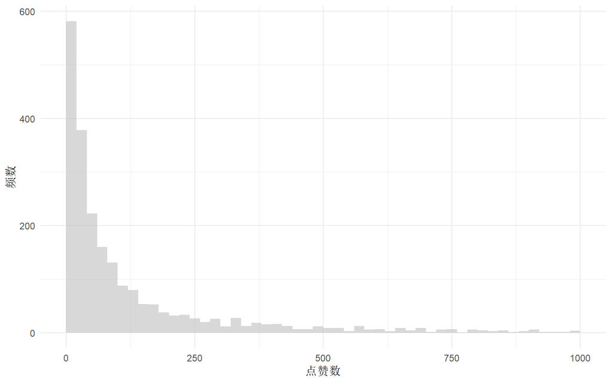

```r
library(ggplot2)
ggplot(data, aes(x = 点赞数)) +
    geom_histogram(alpha = 0.6,
                   fill = "grey",
                   breaks = seq(0, 1000, by = 20)) +
    theme_minimal() +
  labs(x="点赞数", y = "频数")
```

可以看到，点赞数呈明显右偏分布。因此，建立对数线性模型时，对点赞数进行了对数处理。

## 2.2 相关系数矩阵图

```r
library(ggcorrplot)
#选出定量变量，不包括"对数点赞数"
df_num <- dplyr::select_if(data[,1:18], is.numeric)
#计算相关系数
r <- cor(df_num, use="complete.obs")
round(r,2)
```

```
##          点赞数  长度 会员等级 关注数 粉丝数 微博数
## 点赞数     1.00 -0.03     0.09   0.01   0.19   0.02
## 长度      -0.03  1.00    -0.05   0.01   0.06   0.06
## 会员等级   0.09 -0.05     1.00   0.16   0.21   0.20
## 关注数     0.01  0.01     0.16   1.00   0.26   0.33
## 粉丝数     0.19  0.06     0.21   0.26   1.00   0.59
## 微博数     0.02  0.06     0.20   0.33   0.59   1.00
```

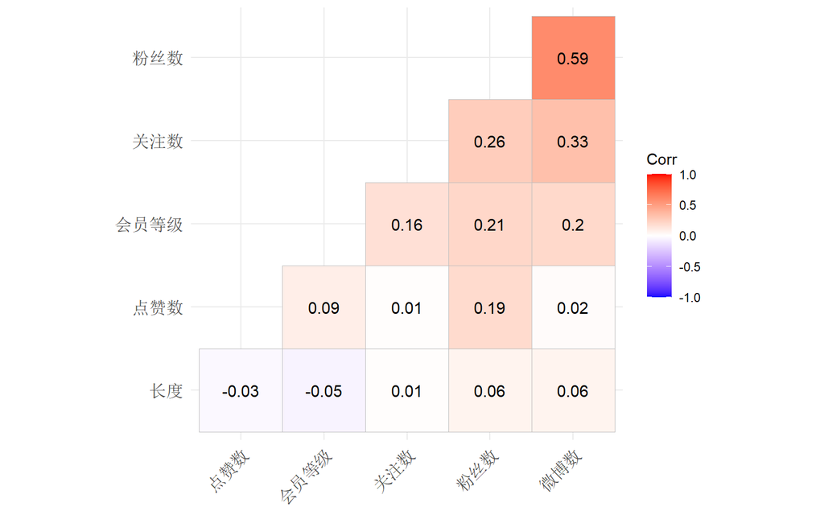

```r
ggcorrplot(r,
           hc.order = TRUE,
           type = "lower",
           lab = TRUE)
```

可以看到，粉丝数与微博数的相关系数最大，为0.59，呈明显正相关；

关注数、会员等级、点赞数、粉丝数之间都呈现正相关关系。

## 2.3 自变量

### (1)微博认证

以微博认证为横轴，对数点赞数为纵轴，画出箱线图。其中，箱子的宽度与样本量正相关。

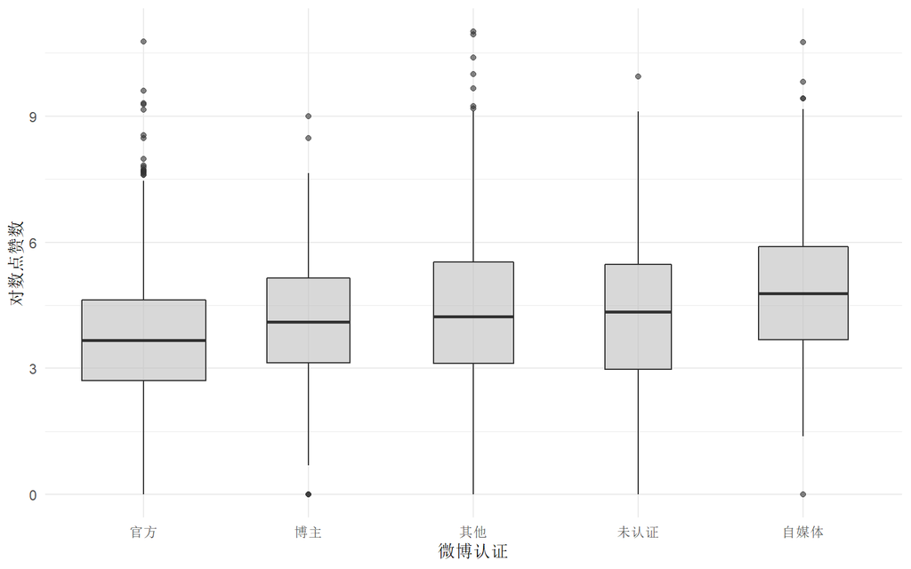

```r
library(ggplot2)

data_plot <- data
#根据点赞数的中位数大小将微博认证的5个水平排序
data_plot$微博认证 <- reorder(data_plot$微博认证, data_plot$点赞数, median)

ggplot(data_plot, aes(x = 微博认证,y = 对数点赞数))+
  geom_boxplot(fill = "grey", alpha = 0.6, varwidth=TRUE)+
    theme_minimal() +
  labs(x="微博认证", y = "对数点赞数")
```

可以看到，在5类微博认证下，都有部分点赞数较高的异常值。

推测部分点赞数较多的微博可能是文字、内容引起了大家的共鸣等，即原因来自微博本身的信息，而不是博主。

由于异常值的印象，箱子之间的差异不是很明显。所以以下去除异常值后，以点赞数为纵坐标画出箱线图，进一步比较微博认证下点赞数的多少。

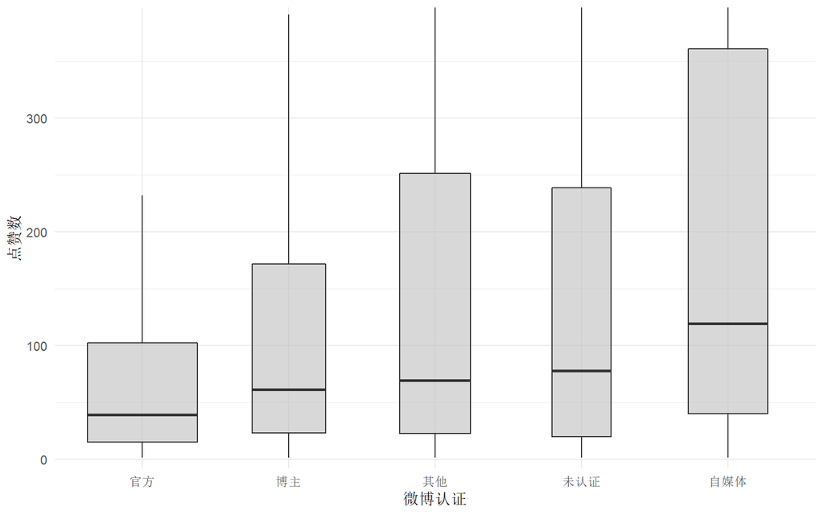

```r
#去除异常值后的分组箱线图，纵坐标为点赞数
ggplot(data_plot, aes(x = 微博认证,y = 点赞数)) +
#去除异常值
  geom_boxplot(fill = "grey", alpha = 0.6, outlier.shape = NA, varwidth=TRUE) +
#调整y轴的范围
  coord_cartesian(ylim = quantile(data$点赞数, c(0.1, 0.85))) +
  theme_minimal() +
  labs(x="微博认证", y = "点赞数")
```

从箱子的宽度可以看到，官方的微博最多，

但是官方的微博点赞数最少，多数都小于100赞；

自媒体的点赞数较多，超过一半的微博点赞数大于100。

### (2)时段

以时段为横坐标，分别画出纵坐标为对数点赞数和去除异常值后的点赞数的箱线图。

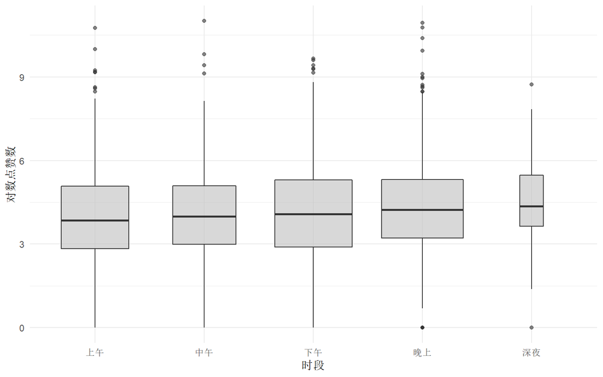

```r
#根据点赞数的中位数对时段排序
data_plot$时段 <- reorder(data_plot$时段, data_plot$点赞数, median)
ggplot(data_plot, aes(x = 时段,y = 对数点赞数))+
  geom_boxplot(fill = "grey", alpha = 0.6, varwidth=TRUE)+
    theme_minimal() +
  labs(x="时段", y = "对数点赞数")
```

与微博认证的结果相似，每一时段都有一些点赞数较多的微博。

下面去掉异常值后，画出以点赞数为纵坐标的箱线图，进一步并比较不同时段的微博的点赞数。

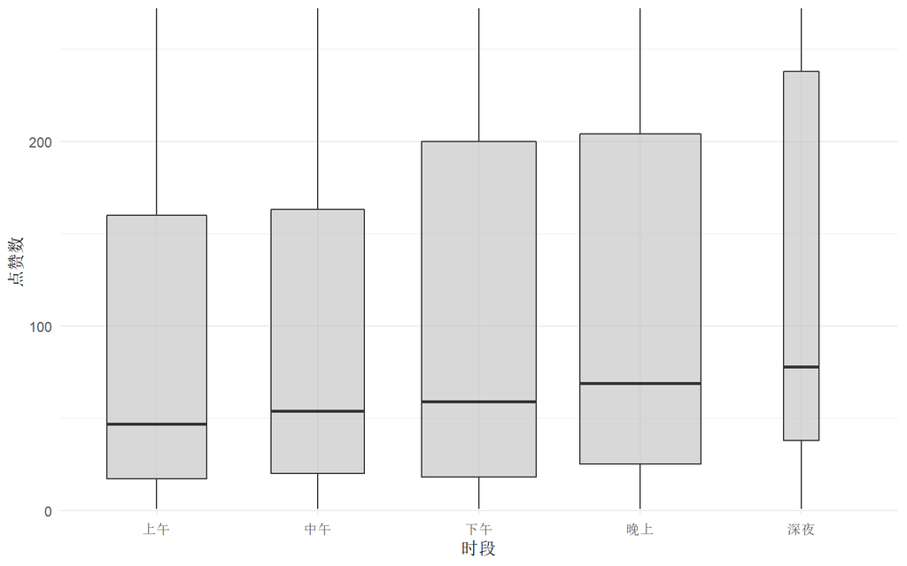

```r
#去除异常值后的分组箱线图
ggplot(data_plot, aes(x = 时段,y = 点赞数)) +
#去除异常值
  geom_boxplot(fill = "grey", alpha = 0.6, outlier.shape = NA, varwidth=TRUE) +
#调整y轴的范围
  coord_cartesian(ylim = quantile(data$点赞数, c(0.1, 0.80))) +
  theme_minimal() +
  labs(x="时段", y = "点赞数")
```

可以看到，尽管深夜发出的微博数最少，点赞数确是最多的；

晚上发出的微博数最多，点赞数仅次于深夜发出的微博。

### (3)粉丝数

```r
max(data$粉丝数)
```

```
## [1] 91427189
```

```r
min(data$粉丝数)
```

```
## [1] 53
```

```r
#对粉丝数离散化，可以看到大多数微博的粉丝数都在小于一百万，粉丝数超过一百万的博主较少
table(discretize(data$粉丝数, method = "cluster", breaks = 5, ordered_result = TRUE))
```

```
##
##       [53,3.03e+06) [3.03e+06,1.09e+07)  [1.09e+07,2.9e+07)  [2.9e+07,5.79e+07)
##                1660                 415                 172                  51
## [5.79e+07,9.14e+07]
##                  51
```

以下以取对数后的粉丝数为横坐标，对数后的点赞数为纵坐标，并用颜色对表示是否为博物馆认证，画出散点图。

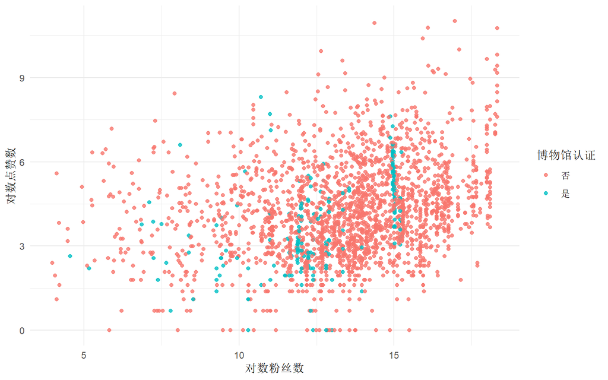

```r
ggplot(data, aes(x = log(粉丝数), y = 对数点赞数, col = 博物馆认证)) +
  geom_point(alpha = 0.8) +
  theme_minimal() +
  labs(x = "对数粉丝数")
```

可以看到，大多数微博的博主没有博物馆认证，而且点赞数最多的微博都是由没有博物馆认证的博主发出的。

由于样本量较大(n=2349)，可以进行分箱化处理。颜色较深处表示此处重叠的点较多。

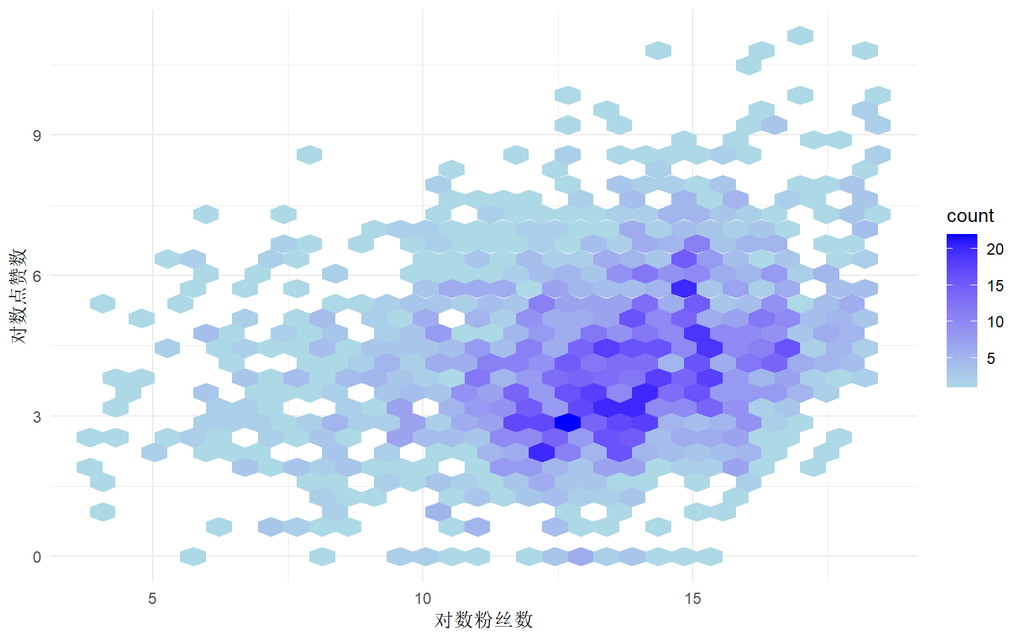

```r
library(hexbin)
ggplot(data, aes(x = log(粉丝数), y = 对数点赞数)) +
  geom_point(alpha = 0.01) +
  theme_minimal() +
  labs(x = "对数粉丝数") +
  stat_binhex() +
  scale_fill_gradient(low = "lightblue", high = "blue")
```

可以看到，大多数微博的粉丝数和点赞数都集中在散点图中部；

粉丝数与点赞数呈现正相关关系。

### (4)长度、是否有视频

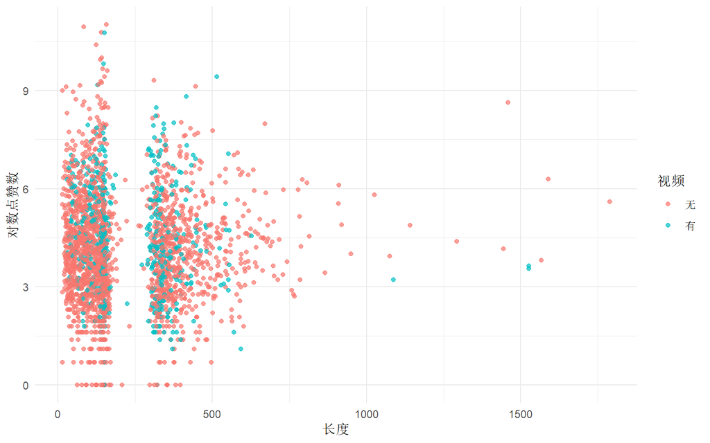

```r
ggplot(data, aes(x = 长度, y = 对数点赞数, col = 视频)) +
  geom_point(alpha = 0.7) +
  theme_minimal() +
  labs(x = "长度")
```

可以看到，长度比较明显地分为了较长和较短的两类；

点赞数最多的微博集中在较短的一类中。

### (5)时间

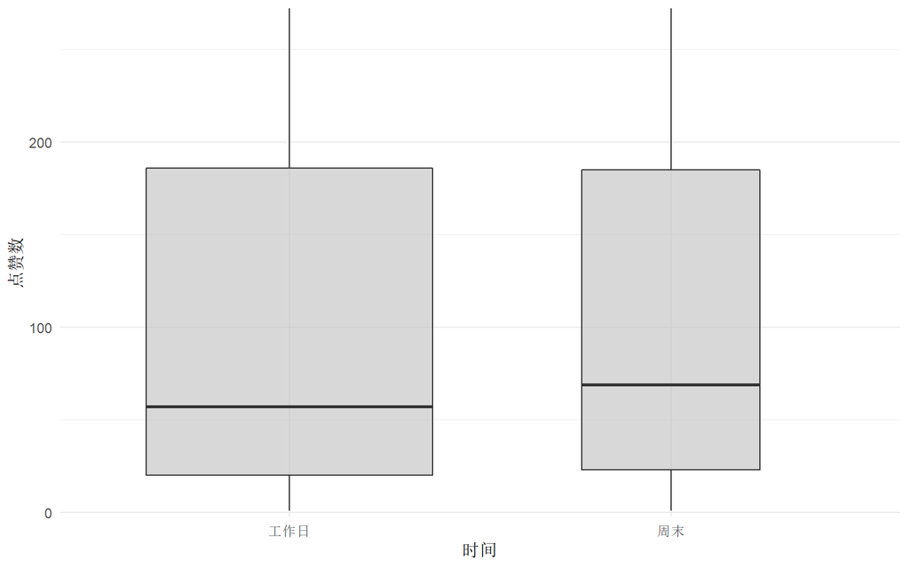

```r
#去除异常值后的分组箱线图
ggplot(data_plot, aes(x = 时间,y = 点赞数)) +
#去除异常值
  geom_boxplot(fill = "grey", alpha = 0.6, outlier.shape = NA, varwidth=TRUE) +
#调整y轴的范围
  coord_cartesian(ylim = quantile(data$点赞数, c(0.1, 0.80))) +
  theme_minimal() +
  labs(x="时间", y = "点赞数")
```

可以看到，周末的微博点赞数更多；工作日发的微博更多。

# 3.回归模型

## 3.1 建立多元线性回归模型

对因变量"点赞数"进行对数处理

```r
#对因变量"点赞数"进行对数处理
mod_lm <- lm(对数点赞数~(地区 + 类型 + 关键词 + 视频 + 长度 + 提到数 +
    话题数 + 性别 + 会员等级 + 微博认证 + 博物馆认证 + 关注数 + 粉丝数 + 微博数 +
    文章数 + 时间 + 时段), data = data)
summary(mod_lm)
```

```
##
## Call:
## lm(formula = 对数点赞数 ~ (地区 + 类型 + 关键词 + 视频 + 长度 +
##     提到数 + 话题数 + 性别 + 会员等级 + 微博认证 + 博物馆认证 +
##     关注数 + 粉丝数 + 微博数 + 文章数 + 时间 + 时段), data = data)
##
## Residuals:
##     Min      1Q  Median      3Q     Max
## -4.2923 -0.8992 -0.0564  0.8135  6.5993
##
## Coefficients:
##                   Estimate Std. Error t value Pr(>|t|)
## (Intercept)      3.660e+00  1.499e-01  24.412  < 2e-16 ***
## 地区国外         1.549e-01  1.095e-01   1.414 0.157409
## 地区华北地区     3.626e-01  8.874e-02   4.086 4.53e-05 ***
## 地区华东地区     1.276e-02  1.191e-01   0.107 0.914674
## 地区西北地区    -7.649e-02  1.055e-01  -0.725 0.468391
## 地区西南地区    -2.851e-01  1.226e-01  -2.326 0.020102 *
## 类型文遗        -3.049e-01  8.724e-02  -3.495 0.000484 ***
## 类型文艺        -2.722e-01  8.302e-02  -3.279 0.001058 **
## 类型文娱        -1.599e-01  8.601e-02  -1.859 0.063205 .
## 类型周边        -3.924e-01  1.390e-01  -2.822 0.004810 **
## 关键词仅博物馆   6.763e-01  7.608e-02   8.890  < 2e-16 ***
## 关键词仅文创     8.747e-01  8.199e-02  10.668  < 2e-16 ***
## 视频有           3.670e-01  7.158e-02   5.127 3.20e-07 ***
## 长度             9.154e-05  1.796e-04   0.510 0.610368
## 提到数有         2.274e-02  6.572e-02   0.346 0.729348
## 话题数大于1个   -1.631e-01  7.298e-02  -2.234 0.025565 *
## 话题数仅有1个   -1.415e-01  7.717e-02  -1.834 0.066826 .
## 性别女           2.767e-01  6.200e-02   4.462 8.49e-06 ***
## 会员等级         1.850e-01  1.169e-02  15.825  < 2e-16 ***
## 微博认证博主    -4.637e-01  1.039e-01  -4.465 8.39e-06 ***
## 微博认证官方    -2.430e-01  8.959e-02  -2.713 0.006719 **
## 微博认证未认证  -2.671e-01  1.184e-01  -2.255 0.024214 *
## 微博认证自媒体  -4.763e-02  9.976e-02  -0.477 0.633071
## 博物馆认证是    -1.149e-01  1.072e-01  -1.072 0.283731
## 关注数          -8.070e-05  2.583e-05  -3.124 0.001806 **
## 粉丝数           4.705e-08  2.924e-09  16.091  < 2e-16 ***
## 微博数          -7.642e-06  1.033e-06  -7.396 1.95e-13 ***
## 文章数(0, 50]   -4.351e-01  8.571e-02  -5.076 4.16e-07 ***
## 文章数(50, 150] -6.259e-01  1.077e-01  -5.813 7.00e-09 ***
## 文章数超过150   -8.947e-01  9.978e-02  -8.967  < 2e-16 ***
## 时间周末         7.015e-02  6.481e-02   1.082 0.279166
## 时段深夜         2.410e-01  1.890e-01   1.275 0.202362
## 时段晚上         7.988e-02  8.111e-02   0.985 0.324793
## 时段下午         6.613e-02  8.225e-02   0.804 0.421465
## 时段中午         2.550e-02  9.073e-02   0.281 0.778731
## ---
## Signif. codes:  0 '***' 0.001 '**' 0.01 '*' 0.05 '.' 0.1 ' ' 1
##
## Residual standard error: 1.361 on 2314 degrees of freedom
## Multiple R-squared:  0.3607, Adjusted R-squared:  0.3513
## F-statistic: 38.39 on 34 and 2314 DF,  p-value: < 2.2e-16
```

```r
library(car)
vif(mod_lm)
```

```
##                GVIF Df GVIF^(1/(2*Df))
## 地区       1.758641  5        1.058078
## 类型       1.546544  4        1.056016
## 关键词     1.544388  2        1.114780
## 视频       1.142943  1        1.069085
## 长度       1.382044  1        1.175603
## 提到数     1.117749  1        1.057237
## 话题数     1.463159  2        1.099823
## 性别       1.104024  1        1.050726
## 会员等级   1.298266  1        1.139415
## 微博认证   2.008981  4        1.091119
## 博物馆认证 1.185960  1        1.089018
## 关注数     1.207178  1        1.098716
## 粉丝数     1.742029  1        1.319860
## 微博数     1.974875  1        1.405303
## 文章数     1.643746  3        1.086357
## 时间       1.071105  1        1.034942
## 时段       1.124764  4        1.014805
```

```r
#AIC
summary(step(mod_lm, k = 2, trace = 0))
```

```
##
## Call:
## lm(formula = 对数点赞数 ~ 地区 + 类型 + 关键词 + 视频 + 话题数 +
##     性别 + 会员等级 + 微博认证 + 关注数 + 粉丝数 + 微博数 + 文章数,
##     data = data)
##
## Residuals:
##     Min      1Q  Median      3Q     Max
## -4.2666 -0.9006 -0.0537  0.8015  6.6162
##
## Coefficients:
##                   Estimate Std. Error t value Pr(>|t|)
## (Intercept)      3.710e+00  1.358e-01  27.326  < 2e-16 ***
## 地区国外         1.712e-01  1.081e-01   1.584 0.113398
## 地区华北地区     3.701e-01  8.802e-02   4.204 2.72e-05 ***
## 地区华东地区     3.483e-02  1.176e-01   0.296 0.767058
## 地区西北地区    -5.473e-02  1.044e-01  -0.524 0.600011
## 地区西南地区    -2.962e-01  1.217e-01  -2.434 0.015019 *
## 类型文遗        -3.024e-01  8.586e-02  -3.521 0.000438 ***
## 类型文艺        -2.648e-01  8.130e-02  -3.257 0.001141 **
## 类型文娱        -1.466e-01  8.395e-02  -1.746 0.080964 .
## 类型周边        -4.034e-01  1.379e-01  -2.924 0.003488 **
## 关键词仅博物馆   6.859e-01  7.502e-02   9.144  < 2e-16 ***
## 关键词仅文创     9.005e-01  8.009e-02  11.243  < 2e-16 ***
## 视频有           3.799e-01  7.090e-02   5.358 9.26e-08 ***
## 话题数大于1个   -1.537e-01  6.928e-02  -2.218 0.026650 *
## 话题数仅有1个   -1.492e-01  7.546e-02  -1.977 0.048178 *
## 性别女           2.825e-01  6.158e-02   4.588 4.72e-06 ***
## 会员等级         1.842e-01  1.163e-02  15.846  < 2e-16 ***
## 微博认证博主    -4.361e-01  1.017e-01  -4.288 1.87e-05 ***
## 微博认证官方    -2.474e-01  8.908e-02  -2.777 0.005522 **
## 微博认证未认证  -2.378e-01  1.172e-01  -2.029 0.042599 *
## 微博认证自媒体  -3.921e-02  9.940e-02  -0.394 0.693308
## 关注数          -8.041e-05  2.562e-05  -3.138 0.001723 **
## 粉丝数           4.691e-08  2.911e-09  16.114  < 2e-16 ***
## 微博数          -7.350e-06  1.016e-06  -7.234 6.33e-13 ***
## 文章数(0, 50]   -4.325e-01  8.540e-02  -5.064 4.43e-07 ***
## 文章数(50, 150] -6.289e-01  1.069e-01  -5.883 4.60e-09 ***
## 文章数超过150   -8.942e-01  9.854e-02  -9.075  < 2e-16 ***
## ---
## Signif. codes:  0 '***' 0.001 '**' 0.01 '*' 0.05 '.' 0.1 ' ' 1
##
## Residual standard error: 1.36 on 2322 degrees of freedom
## Multiple R-squared:  0.3592, Adjusted R-squared:  0.352
## F-statistic: 50.05 on 26 and 2322 DF,  p-value: < 2.2e-16
```

```r
#BIC
summary(step(mod_lm, k = log(nrow(data)), trace = 0))
```

```
##
## Call:
## lm(formula = 对数点赞数 ~ 关键词 + 视频 + 性别 + 会员等级 + 关注数 +
##     粉丝数 + 微博数 + 文章数, data = data)
##
## Residuals:
##     Min      1Q  Median      3Q     Max
## -4.4895 -0.9055 -0.0750  0.8016  6.6642
##
## Coefficients:
##                   Estimate Std. Error t value Pr(>|t|)
## (Intercept)      3.247e+00  9.913e-02  32.751  < 2e-16 ***
## 关键词仅博物馆   7.192e-01  7.056e-02  10.193  < 2e-16 ***
## 关键词仅文创     9.848e-01  7.571e-02  13.006  < 2e-16 ***
## 视频有           3.780e-01  6.948e-02   5.441 5.85e-08 ***
## 性别女           3.104e-01  6.147e-02   5.049 4.78e-07 ***
## 会员等级         1.919e-01  1.096e-02  17.511  < 2e-16 ***
## 关注数          -8.186e-05  2.558e-05  -3.201  0.00139 **
## 粉丝数           5.036e-08  2.884e-09  17.465  < 2e-16 ***
## 微博数          -7.572e-06  9.996e-07  -7.575 5.13e-14 ***
## 文章数(0, 50]   -4.763e-01  8.439e-02  -5.644 1.86e-08 ***
## 文章数(50, 150] -7.223e-01  1.033e-01  -6.991 3.55e-12 ***
## 文章数超过150   -9.615e-01  9.413e-02 -10.215  < 2e-16 ***
## ---
## Signif. codes:  0 '***' 0.001 '**' 0.01 '*' 0.05 '.' 0.1 ' ' 1
##
## Residual standard error: 1.381 on 2337 degrees of freedom
## Multiple R-squared:  0.3349, Adjusted R-squared:  0.3318
## F-statistic:   107 on 11 and 2337 DF,  p-value: < 2.2e-16
```

AIC准则保留的变量有12个：

地区，类型，关键词，视频，话题数，性别，会员等级，微博认证，关注数，粉丝数，微博数，文章数；

得到的调整后R²=0.352；

BIC准则保留的变量有8个：

关键词，视频，性别，会员等级，关注数，粉丝数，微博数，文章数；

得到的调整后R²=0.3318。

BIC准则选择的8个变量包含在AIC准则选择的12个变量中，

AIC准则选择的，但是BIC准则没有选择的有地区、类型、话题数、微博认证，

其中，"地区"仅有"华北地区"是显著的，其余水平均不显著，而且从实际来看，点赞量一般与地区没有明显关联，所以去掉"地区"变量；

因此，综合考虑，最终保留11个变量，分别是

类型，关键词，视频，话题数，性别，会员等级，微博认证，关注数，粉丝数，微博数，文章数；

```r
mod_res <- lm(对数点赞数~(类型 + 关键词 + 视频 + 话题数 +
    性别 + 会员等级 + 微博认证 + 关注数 + 粉丝数 + 微博数 + 文章数), data = data)
summary(mod_res)
```

```
##
## Call:
## lm(formula = 对数点赞数 ~ (类型 + 关键词 + 视频 + 话题数 + 性别 +
##     会员等级 + 微博认证 + 关注数 + 粉丝数 + 微博数 + 文章数),
##     data = data)
##
## Residuals:
##     Min      1Q  Median      3Q     Max
## -4.6042 -0.9075 -0.0682  0.8065  6.9042
##
## Coefficients:
##                   Estimate Std. Error t value Pr(>|t|)
## (Intercept)      3.733e+00  1.330e-01  28.066  < 2e-16 ***
## 类型文遗        -2.970e-01  8.458e-02  -3.512 0.000454 ***
## 类型文艺        -2.874e-01  8.133e-02  -3.534 0.000418 ***
## 类型文娱        -1.707e-01  8.407e-02  -2.030 0.042463 *
## 类型周边        -3.526e-01  1.383e-01  -2.551 0.010817 *
## 关键词仅博物馆   6.876e-01  7.221e-02   9.522  < 2e-16 ***
## 关键词仅文创     9.321e-01  7.761e-02  12.009  < 2e-16 ***
## 视频有           3.867e-01  7.041e-02   5.491 4.42e-08 ***
## 话题数大于1个   -1.538e-01  6.917e-02  -2.224 0.026249 *
## 话题数仅有1个   -1.512e-01  7.561e-02  -2.000 0.045596 *
## 性别女           2.871e-01  6.183e-02   4.643 3.62e-06 ***
## 会员等级         1.879e-01  1.166e-02  16.110  < 2e-16 ***
## 微博认证博主    -4.376e-01  1.018e-01  -4.299 1.79e-05 ***
## 微博认证官方    -2.251e-01  8.908e-02  -2.527 0.011567 *
## 微博认证未认证  -2.486e-01  1.172e-01  -2.122 0.033945 *
## 微博认证自媒体  -4.439e-02  9.905e-02  -0.448 0.654107
## 关注数          -8.198e-05  2.573e-05  -3.187 0.001459 **
## 粉丝数           4.876e-08  2.905e-09  16.783  < 2e-16 ***
## 微博数          -7.696e-06  1.010e-06  -7.617 3.75e-14 ***
## 文章数(0, 50]   -4.388e-01  8.583e-02  -5.112 3.45e-07 ***
## 文章数(50, 150] -6.585e-01  1.072e-01  -6.141 9.59e-10 ***
## 文章数超过150   -8.883e-01  9.884e-02  -8.988  < 2e-16 ***
## ---
## Signif. codes:  0 '***' 0.001 '**' 0.01 '*' 0.05 '.' 0.1 ' ' 1
##
## Residual standard error: 1.368 on 2327 degrees of freedom
## Multiple R-squared:  0.3505, Adjusted R-squared:  0.3446
## F-statistic:  59.8 on 21 and 2327 DF,  p-value: < 2.2e-16
```

调整后R²=0.3446，较低，

可能是因为有其他与点赞数有关的重要变量未包含在数据中，如微博的内容，视频的长度，话题为超话还是普通话题，是否包含抽奖等；

由于调整后R²较低，接下来在现有数据的基础上，对粉丝数、关注数、微博数、长度进行离散化后再进行回归，调整后R²得到提高。

## 3.2 对粉丝数、关注数、微博数、长度进行离散化

```r
data_fac <- data
n_br <- 8
data_fac$长度 <- discretize(data$长度, method = "frequency", breaks = n_br, ordered_result = FALSE, label = c("[14,60)", "[60,97)", "[97,128)", "[128,149)", "[149,307)", "[307,347)", "[347,417)", "[417,1790]"))
data_fac$关注数 <- discretize(data$关注数, method = "frequency", breaks = n_br, ordered_result = FALSE, label = c("[0,164)", "[164,268)", "[268,389)", "[389,581)", "[581,763)", "[763,1036)", "[1036,1841)", "[1841, 20000]"))
data_fac$微博数 <- discretize(data$微博数, method = "frequency", breaks = n_br, ordered_result = FALSE, label = c("[5,1539)","[1539,3694)","[3694,7595.5)","[7595.5,12686)","[12686,20626)","[20626,38062)","[38062,73038)","[73038,295520]"))
data_fac$粉丝数 <- discretize(data$粉丝数, method = "frequency", breaks = n_br, ordered_result = FALSE, label = c("[53,32682)","[32682,153304)","[153304,353830)","[353830,807823)","[807823,1600898)","[1600898,3583204)","[3583204,9429162)","[9429162,91427189]"))
```

接下来采用离散化后的变量建立回归模型。

```r
#对因变量"点赞数"进行对数处理
mod_lm_fac <- lm(对数点赞数~(地区 + 类型 + 关键词 + 视频 + 长度 + 提到数 +
    话题数 + 性别 + 会员等级 + 微博认证 + 博物馆认证 + 关注数 + 粉丝数 + 微博数 +
    文章数 + 时间 + 时段), data = data_fac)
summary(mod_lm_fac)
```

```
##
## Call:
## lm(formula = 对数点赞数 ~ (地区 + 类型 + 关键词 + 视频 + 长度 +
##     提到数 + 话题数 + 性别 + 会员等级 + 微博认证 + 博物馆认证 +
##     关注数 + 粉丝数 + 微博数 + 文章数 + 时间 + 时段), data = data_fac)
##
## Residuals:
##     Min      1Q  Median      3Q     Max
## -4.0588 -0.8307 -0.0547  0.7352  6.2494
##
## Coefficients:
##                           Estimate Std. Error t value Pr(>|t|)
## (Intercept)               3.613631   0.184008  19.638  < 2e-16 ***
## 地区国外                  0.054305   0.104892   0.518 0.604700
## 地区华北地区              0.288060   0.084881   3.394 0.000701 ***
## 地区华东地区             -0.086182   0.113487  -0.759 0.447690
## 地区西北地区             -0.015099   0.101355  -0.149 0.881589
## 地区西南地区             -0.184585   0.119190  -1.549 0.121600
## 类型文遗                 -0.361895   0.084522  -4.282 1.93e-05 ***
## 类型文艺                 -0.291113   0.080406  -3.621 0.000300 ***
## 类型文娱                 -0.304253   0.084074  -3.619 0.000302 ***
## 类型周边                 -0.435374   0.133691  -3.257 0.001144 **
## 关键词仅博物馆            0.696960   0.073798   9.444  < 2e-16 ***
## 关键词仅文创              0.846466   0.078719  10.753  < 2e-16 ***
## 视频有                    0.265245   0.069787   3.801 0.000148 ***
## 长度[60,97)              -0.064635   0.110785  -0.583 0.559660
## 长度[97,128)              0.120238   0.112686   1.067 0.286074
## 长度[128,149)             0.246777   0.118548   2.082 0.037484 *
## 长度[149,307)             0.096659   0.118674   0.814 0.415445
## 长度[307,347)             0.099595   0.124823   0.798 0.425016
## 长度[347,417)            -0.005632   0.123164  -0.046 0.963532
## 长度[417,1790]            0.181984   0.122574   1.485 0.137763
## 提到数有                  0.060793   0.063934   0.951 0.341766
## 话题数大于1个            -0.156890   0.072391  -2.167 0.030317 *
## 话题数仅有1个            -0.126541   0.075389  -1.679 0.093384 .
## 性别女                    0.208213   0.060220   3.458 0.000555 ***
## 会员等级                  0.129706   0.011801  10.991  < 2e-16 ***
## 微博认证博主             -0.325772   0.101755  -3.202 0.001386 **
## 微博认证官方             -0.259453   0.085558  -3.032 0.002453 **
## 微博认证未认证            0.176711   0.118031   1.497 0.134491
```

[output cut: 22 more lines]

```
## 微博数[73038,295520]     -1.924017   0.154081 -12.487  < 2e-16 ***
## 文章数(0, 50]            -0.317651   0.083671  -3.796 0.000151 ***
## 文章数(50, 150]          -0.424522   0.107665  -3.943 8.29e-05 ***
## 文章数超过150            -0.609816   0.100280  -6.081 1.39e-09 ***
## 时间周末                  0.016233   0.061626   0.263 0.792262
## 时段深夜                  0.292930   0.180391   1.624 0.104542
## 时段晚上                  0.017628   0.077770   0.227 0.820703
## 时段下午                  0.002633   0.078650   0.033 0.973300
## 时段中午                 -0.058675   0.086602  -0.678 0.498141
## ---
## Signif. codes:  0 '***' 0.001 '**' 0.01 '*' 0.05 '.' 0.1 ' ' 1
##
## Residual standard error: 1.289 on 2290 degrees of freedom
## Multiple R-squared:  0.4325, Adjusted R-squared:  0.4182
## F-statistic: 30.09 on 58 and 2290 DF,  p-value: < 2.2e-16
```

```r
#AIC
summary(step(mod_lm_fac, k = 2, trace = 0))
```

```
##
## Call:
## lm(formula = 对数点赞数 ~ 地区 + 类型 + 关键词 + 视频 + 话题数 +
##     性别 + 会员等级 + 微博认证 + 博物馆认证 + 关注数 + 粉丝数 +
##     微博数 + 文章数, data = data_fac)
##
## Residuals:
##     Min      1Q  Median      3Q     Max
## -4.1388 -0.8433 -0.0528  0.7210  6.2232
##
## Coefficients:
##                           Estimate Std. Error t value Pr(>|t|)
## (Intercept)               3.717315   0.162138  22.927  < 2e-16 ***
## 地区国外                  0.074906   0.103792   0.722 0.470556
## 地区华北地区              0.300486   0.083916   3.581 0.000350 ***
## 地区华东地区             -0.039864   0.112135  -0.356 0.722245
## 地区西北地区             -0.007454   0.100012  -0.075 0.940591
## 地区西南地区             -0.173108   0.118235  -1.464 0.143302
## 类型文遗                 -0.335621   0.082163  -4.085 4.56e-05 ***
## 类型文艺                 -0.252043   0.077383  -3.257 0.001142 **
## 类型文娱                 -0.263256   0.080335  -3.277 0.001065 **
## 类型周边                 -0.406213   0.132140  -3.074 0.002136 **
## 关键词仅博物馆            0.686455   0.072106   9.520  < 2e-16 ***
## 关键词仅文创              0.845933   0.077884  10.861  < 2e-16 ***
## 视频有                    0.269926   0.068559   3.937 8.49e-05 ***
## 话题数大于1个            -0.149079   0.066728  -2.234 0.025571 *
## 话题数仅有1个            -0.116326   0.072554  -1.603 0.109005
## 性别女                    0.210161   0.060137   3.495 0.000484 ***
## 会员等级                  0.129908   0.011763  11.044  < 2e-16 ***
## 微博认证博主             -0.325805   0.100925  -3.228 0.001263 **
## 微博认证官方             -0.248005   0.085088  -2.915 0.003595 **
## 微博认证未认证            0.174256   0.117474   1.483 0.138117
## 微博认证自媒体            0.102459   0.096097   1.066 0.286441
## 博物馆认证是             -0.162432   0.106065  -1.531 0.125799
## 关注数[164,268)          -0.260683   0.109699  -2.376 0.017566 *
## 关注数[268,389)          -0.329691   0.110022  -2.997 0.002759 **
## 关注数[389,581)          -0.115392   0.111039  -1.039 0.298820
## 关注数[581,763)          -0.229947   0.114216  -2.013 0.044202 *
## 关注数[763,1036)         -0.046123   0.115188  -0.400 0.688891
## 关注数[1036,1841)        -0.124905   0.116258  -1.074 0.282764
```

[output cut: 9 more lines]

```
## 微博数[3694,7595.5)      -0.725744   0.116742  -6.217 6.01e-10 ***
## 微博数[7595.5,12686)     -0.994976   0.121901  -8.162 5.35e-16 ***
## 微博数[12686,20626)      -1.057665   0.126038  -8.392  < 2e-16 ***
## 微博数[20626,38062)      -1.593474   0.128904 -12.362  < 2e-16 ***
## 微博数[38062,73038)      -1.726762   0.138137 -12.500  < 2e-16 ***
## 微博数[73038,295520]     -1.929859   0.152684 -12.640  < 2e-16 ***
## 文章数(0, 50]            -0.324199   0.083504  -3.882 0.000106 ***
## 文章数(50, 150]          -0.430665   0.107221  -4.017 6.09e-05 ***
## 文章数超过150            -0.627719   0.099646  -6.300 3.57e-10 ***
## ---
## Signif. codes:  0 '***' 0.001 '**' 0.01 '*' 0.05 '.' 0.1 ' ' 1
##
## Residual standard error: 1.29 on 2303 degrees of freedom
## Multiple R-squared:  0.4283, Adjusted R-squared:  0.4172
## F-statistic: 38.35 on 45 and 2303 DF,  p-value: < 2.2e-16
```

```r
#BIC
summary(step(mod_lm_fac, k = log(nrow(data)), trace = 0))
```

```
##
## Call:
## lm(formula = 对数点赞数 ~ 关键词 + 视频 + 性别 + 会员等级 + 微博认证 +
##     粉丝数 + 微博数 + 文章数, data = data_fac)
##
## Residuals:
##     Min      1Q  Median      3Q     Max
## -4.5627 -0.8322 -0.0695  0.7393  5.9691
##
## Coefficients:
##                          Estimate Std. Error t value Pr(>|t|)
## (Intercept)               3.27244    0.14126  23.166  < 2e-16 ***
## 关键词仅博物馆            0.72908    0.06794  10.731  < 2e-16 ***
## 关键词仅文创              0.95759    0.07227  13.251  < 2e-16 ***
## 视频有                    0.26667    0.06660   4.004 6.42e-05 ***
## 性别女                    0.22168    0.06005   3.692 0.000228 ***
## 会员等级                  0.13170    0.01176  11.199  < 2e-16 ***
## 微博认证博主             -0.29843    0.09872  -3.023 0.002530 **
## 微博认证官方             -0.25072    0.08463  -2.963 0.003081 **
## 微博认证未认证            0.25519    0.11589   2.202 0.027767 *
## 微博认证自媒体            0.13689    0.09506   1.440 0.149970
## 粉丝数[32682,153304)      0.65595    0.11308   5.801 7.51e-09 ***
## 粉丝数[153304,353830)     0.87952    0.11931   7.371 2.34e-13 ***
## 粉丝数[353830,807823)     0.92723    0.11876   7.808 8.73e-15 ***
## 粉丝数[807823,1600898)    1.32475    0.12315  10.757  < 2e-16 ***
## 粉丝数[1600898,3583204)   1.91936    0.12707  15.105  < 2e-16 ***
## 粉丝数[3583204,9429162)   1.82617    0.13072  13.970  < 2e-16 ***
## 粉丝数[9429162,91427189]  2.96213    0.14567  20.335  < 2e-16 ***
## 微博数[1539,3694)        -0.70217    0.11337  -6.193 6.94e-10 ***
## 微博数[3694,7595.5)      -0.77104    0.11537  -6.683 2.92e-11 ***
## 微博数[7595.5,12686)     -1.03667    0.11939  -8.683  < 2e-16 ***
## 微博数[12686,20626)      -1.07759    0.12237  -8.806  < 2e-16 ***
## 微博数[20626,38062)      -1.63055    0.12454 -13.093  < 2e-16 ***
## 微博数[38062,73038)      -1.75725    0.13080 -13.435  < 2e-16 ***
## 微博数[73038,295520]     -1.94363    0.14182 -13.705  < 2e-16 ***
## 文章数(0, 50]            -0.36951    0.08370  -4.415 1.06e-05 ***
## 文章数(50, 150]          -0.52639    0.10689  -4.924 9.06e-07 ***
## 文章数超过150            -0.70258    0.09880  -7.111 1.52e-12 ***
## ---
## Signif. codes:  0 '***' 0.001 '**' 0.01 '*' 0.05 '.' 0.1 ' ' 1
##
## Residual standard error: 1.305 on 2322 degrees of freedom
## Multiple R-squared:  0.4102, Adjusted R-squared:  0.4036
## F-statistic: 62.12 on 26 and 2322 DF,  p-value: < 2.2e-16
```

AIC准则保留的变量有13个：

地区，类型，关键词，视频，话题数，性别，会员等级，微博认证，博物馆认证，粉丝数，关注数，微博数，文章数；

得到的调整后R²=0.4172；

BIC准则保留的变量有8个：

得到的调整后R²=0.4036。

**两者的调整后R²都比离散化之前有了较为明显的提高**。

BIC准则选择的8个变量包含在AIC准则选择的13个变量中，

其中，"地区"仅有"华北地区"是显著的，其余水平均不显著，而且从实际来看，点赞量一般与地区没有明显关联，所以去掉"地区"变量；

因此，综合考虑，最终保留11个变量，分别是

类型，关键词，视频，话题数，性别，会员等级，微博认证，关注数，粉丝数，微博数，文章数；

```r
mod_final <- lm(对数点赞数 ~ 类型 + 关键词 + 话题数 + 性别 + 会员等级 + 微博认证 + 关注数 + 粉丝数 + 微博数 + 文章数 + 视频 , data = data_fac)
summary(mod_final)
```

```
##
## Call:
## lm(formula = 对数点赞数 ~ 类型 + 关键词 + 话题数 + 性别 + 会员等级 +
##     微博认证 + 关注数 + 粉丝数 + 微博数 + 文章数 + 视频, data = data_fac)
##
## Residuals:
##     Min      1Q  Median      3Q     Max
## -4.3238 -0.8294 -0.0589  0.7295  6.0996
##
## Coefficients:
##                          Estimate Std. Error t value Pr(>|t|)
## (Intercept)               3.71026    0.15802  23.479  < 2e-16 ***
## 类型文遗                 -0.32900    0.08071  -4.076 4.73e-05 ***
## 类型文艺                 -0.27293    0.07721  -3.535 0.000416 ***
## 类型文娱                 -0.28593    0.08025  -3.563 0.000374 ***
## 类型周边                 -0.38476    0.13208  -2.913 0.003614 **
## 关键词仅博物馆            0.67643    0.06936   9.753  < 2e-16 ***
## 关键词仅文创              0.88535    0.07421  11.931  < 2e-16 ***
## 话题数大于1个            -0.14850    0.06640  -2.236 0.025421 *
## 话题数仅有1个            -0.11466    0.07241  -1.583 0.113465
## 性别女                    0.22016    0.06001   3.669 0.000249 ***
## 会员等级                  0.12934    0.01175  11.010  < 2e-16 ***
## 微博认证博主             -0.29211    0.09869  -2.960 0.003109 **
## 微博认证官方             -0.22881    0.08481  -2.698 0.007029 **
## 微博认证未认证            0.19679    0.11635   1.691 0.090882 .
## 微博认证自媒体            0.11834    0.09525   1.242 0.214219
## 关注数[164,268)          -0.26246    0.10997  -2.387 0.017080 *
## 关注数[268,389)          -0.35623    0.10983  -3.244 0.001197 **
## 关注数[389,581)          -0.13456    0.11085  -1.214 0.224903
## 关注数[581,763)          -0.25591    0.11390  -2.247 0.024748 *
## 关注数[763,1036)         -0.08364    0.11457  -0.730 0.465437
## 关注数[1036,1841)        -0.13791    0.11639  -1.185 0.236181
## 关注数[1841, 20000]      -0.22505    0.12157  -1.851 0.064280 .
## 粉丝数[32682,153304)      0.66084    0.11288   5.854 5.47e-09 ***
## 粉丝数[153304,353830)     0.90953    0.11926   7.626 3.50e-14 ***
## 粉丝数[353830,807823)     0.93220    0.11875   7.850 6.31e-15 ***
## 粉丝数[807823,1600898)    1.36032    0.12292  11.067  < 2e-16 ***
## 粉丝数[1600898,3583204)   1.93970    0.12740  15.226  < 2e-16 ***
## 粉丝数[3583204,9429162)   1.83415    0.13080  14.023  < 2e-16 ***
## 粉丝数[9429162,91427189]  2.99785    0.14507  20.664  < 2e-16 ***
## 微博数[1539,3694)        -0.66032    0.11354  -5.816 6.87e-09 ***
## 微博数[3694,7595.5)      -0.73603    0.11688  -6.298 3.61e-10 ***
## 微博数[7595.5,12686)     -1.00617    0.12196  -8.250 2.63e-16 ***
## 微博数[12686,20626)      -1.09134    0.12597  -8.664  < 2e-16 ***
## 微博数[20626,38062)      -1.60848    0.12827 -12.539  < 2e-16 ***
## 微博数[38062,73038)      -1.75174    0.13683 -12.802  < 2e-16 ***
## 微博数[73038,295520]     -1.95479    0.15082 -12.961  < 2e-16 ***
## 文章数(0, 50]            -0.31950    0.08363  -3.820 0.000137 ***
## 文章数(50, 150]          -0.44502    0.10741  -4.143 3.55e-05 ***
## 文章数超过150            -0.60799    0.09933  -6.121 1.09e-09 ***
## 视频有                    0.28062    0.06781   4.138 3.62e-05 ***
## ---
## Signif. codes:  0 '***' 0.001 '**' 0.01 '*' 0.05 '.' 0.1 ' ' 1
##
## Residual standard error: 1.294 on 2309 degrees of freedom
## Multiple R-squared:  0.4231, Adjusted R-squared:  0.4133
## F-statistic: 43.42 on 39 and 2309 DF,  p-value: < 2.2e-16
```

调整后R²=0.4133

## 3.2 回归诊断

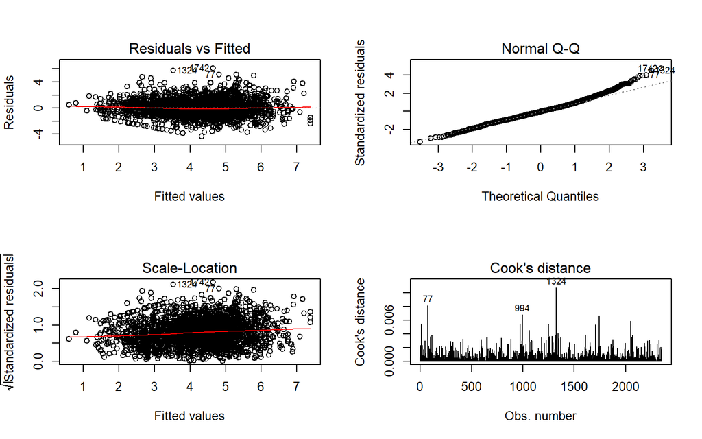

```r
par(mfrow=c(2,2))
plot(mod_final, which=c(1:4))
```

从残差图来看，没有明显的异方差问题；

QQ图接近直线，说明模型基本符合正态假定；

库克距离均小于0.5，可以认为不存在异常值。

```r
#多重共线性
library(car)
vif(mod_final)
```

```
##              GVIF Df GVIF^(1/(2*Df))
## 类型     1.390013  4        1.042023
## 关键词   1.308525  2        1.069536
## 话题数   1.221222  2        1.051232
## 性别     1.143658  1        1.069419
## 会员等级 1.449087  1        1.203780
## 微博认证 2.170990  4        1.101748
## 关注数   2.046041  7        1.052466
## 粉丝数   3.794035  7        1.099928
## 微博数   4.241476  7        1.108722
## 文章数   1.926309  3        1.115461
## 视频     1.134103  1        1.064943
```

VIF值均小于10，可以认为模型中不存在多重共线性问题。

## 3.3 模型解释

由于因变量经过对数处理，所以回归系数解释为"增长率"。

```r
coef <- as.data.frame(mod_final$coefficients)
colnames(coef) <- c("回归系数估计值")
knitr::kable(coef, format = "html")
```

|  | 回归系数估计值 |
| --- | --- |
| (Intercept) | 3.7102564 |
| 类型文遗 | -0.3290013 |
| 类型文艺 | -0.2729261 |
| 类型文娱 | -0.2859266 |
| 类型周边 | -0.3847595 |
| 关键词仅博物馆 | 0.6764307 |
| 关键词仅文创 | 0.8853515 |
| 话题数大于1个 | -0.1485010 |
| 话题数仅有1个 | -0.1146608 |
| 性别女 | 0.2201557 |
| 会员等级 | 0.1293368 |
| 微博认证博主 | -0.2921104 |
| 微博认证官方 | -0.2288148 |
| 微博认证未认证 | 0.1967950 |
| 微博认证自媒体 | 0.1183413 |
| 关注数[164,268) | -0.2624606 |
| 关注数[268,389) | -0.3562329 |
| 关注数[389,581) | -0.1345622 |
| 关注数[581,763) | -0.2559083 |
| 关注数[763,1036) | -0.0836376 |
| 关注数[1036,1841) | -0.1379074 |
| 关注数[1841, 20000] | -0.2250468 |
| 粉丝数[32682,153304) | 0.6608382 |
| 粉丝数[153304,353830) | 0.9095332 |
| 粉丝数[353830,807823) | 0.9322020 |
| 粉丝数[807823,1600898) | 1.3603241 |
| 粉丝数[1600898,3583204) | 1.9396994 |
| 粉丝数[3583204,9429162) | 1.8341530 |
| 粉丝数[9429162,91427189] | 2.9978520 |
| 微博数[1539,3694) | -0.6603156 |
| 微博数[3694,7595.5) | -0.7360321 |
| 微博数[7595.5,12686) | -1.0061673 |
| 微博数[12686,20626) | -1.0913362 |
| 微博数[20626,38062) | -1.6084785 |
| 微博数[38062,73038) | -1.7517448 |
| 微博数[73038,295520] | -1.9547852 |
| 文章数(0, 50] | -0.3194961 |
| 文章数(50, 150] | -0.4450208 |
| 文章数超过150 | -0.6079945 |
| 视频有 | 0.2806245 |

控制其他因素不变时，

1.类型：

基准组为"未知"。

"文遗"，"文艺"，"文娱"，"周边"四个水平的回归系数均为负，

在这"文遗"，"文艺"，"文娱"，"周边"这四个水平中，"文艺"类型的点赞数最多，"文娱"类次之，"周边"类点赞数最低。

2.关键词：

基准组为"博物馆+文创"。

关键词仅文创的微博获得的点赞数最高，仅博物馆的次之，关键词为博物馆+文创的点赞数最低。

原因可能是包含"文创"关键词的微博比"博物馆"关键词的微博更容易吸引大家，

另一个可能的原因是猜测包含"文创"关键词的微博中出现"点赞抽奖"的可能性更大，从而提高了点赞量。

3.话题数：

基准组为"没有话题"。

"话题数大于1个"和"话题数仅有1个"的回归系数均为负，且"话题数大于1个"的回归系数更小，这表明话题数更少，或者不带话题的微博的点赞数越多。

4.性别

基准组为"男"。

5.微博认证

基准组为"其他"。

微博未认证的回归系数最大，表明在其他变量不变时，未认证的博主获得的点赞数更多；微博认证自媒体次之。

6.关注数与粉丝数

关注数的基准组为关注数[0,164)（关注数最少的组），

粉丝数的基准组为粉丝数[53,32682)（粉丝最少的组）；

关注数指博主关注的人的数量，而粉丝数指关注博主的人的数量。

关注数为[0,164)的博主的点赞数最多，关注数为[268,389)的点赞数最少；随着关注数的增加，点赞数可能增加也可能减少。

大致来看，粉丝数越多，微博的点赞数越多。

7.微博数

微博数的基准组为微博数[5,1539)（微博数最少的组），

微博数越多，点赞数越少。

这可能是因为人们更喜欢看到只发有意义、有价值的内容的博主。

8.文章数

文章数的基准组为"无"，

文章数越多，点赞数越少；没有文章的博主的微博的点赞数更多。

这可能是相比长文章，因为微博用户更喜欢短文字。

9.视频

基准组为"没有视频"。

有视频比没有视频的微博的点赞数多28.06%。

10.会员等级

会员等级越高，微博点赞数越多。